# Lab 05. Recap

Прошлый раз мы разбивали тексты не только на отдельные слова (концепция “мешка слов”), но и добавили немного учета контекста и последовательности в анализ, исследуя n-граммы.

В первой части сегодня мы продолжим работать с данными об отелях (уже лемматизированные отзывы)

```r
library(readr)
reviews = read_csv("~/shared/minor2_2018/2-tm-net/lab03-tm/reviews.csv")
# в колонке lem лемматизированные отзывы + нет пунктуации и чисел

library(tidytext)
library(dplyr)
rustopwords = data.frame(words=c(stopwords::stopwords("ru"), "это"), stringsAsFactors=FALSE)
```

**Повторение:** * Что такое n-граммы? * Разбейте отзывы на триграммы. Не забудьте удалить триграммы со стоп-словами.

```r
reviews.trigrams = reviews %>%
  unnest_tokens(..., ..., token = "ngrams", ...)

reviews.trigrams %>%
  dplyr::count(..., sort = TRUE)

reviews.filtered = reviews.trigrams %>%
  separate(..., c("word1", "word2", "word3"), sep = " ") %>%
  filter(word1 ...) %>%
  filter(word2 ...) %>%
  filter(word3 ...)
```

Какая триграмма самая частая? А в отзывах на отели 4*?

```r
reviews.filtered %>%
  dplyr::count(..., sort = TRUE)

reviews.filtered %>% filter(star ...) %>%
  dplyr::count(..., sort = TRUE)
```

А какая триграмма чаще всего встречается в негативных отзывах (оценки меньше 3)?

```r
reviews.filtered %>% filter(rating ...) %>%
  dplyr::count(..., sort = TRUE)
```

Теперь посмотрим на нормализованные частоты (TF-IDF) – их можно считать и n-грамм, не только для отдельных слов. Какие в этом случае самые характерные слова для каждой звезды?

```r
trigram.united <- reviews.filtered %>%
  unite(trigram, word1, word2, word3, sep = " ")

trigram_tf_idf <- trigram.united %>%
  dplyr::count(trigram, stars) %>%
  bind_tf_idf(trigram, stars, n) %>%
  arrange(desc(tf_idf))
```

Для удобства можно нарисовать

```r
plot_trigram <- trigram_tf_idf %>%
  group_by(stars) %>%
  top_n(5)

ggplot(plot_trigram, aes(trigram, tf_idf)) +
  geom_bar(stat = "identity", show.legend = FALSE) +
  labs(x = NULL, y = "tf-idf") +
  facet_wrap(~stars, scales = "free") +
  coord_flip()
```

Общие принципы вспомнили, теперь возвращаемся к содержательному анализу. Зачем мы разбивали на биграммы? Какую дополнительную информацию нам это дало по сравнению с “мешком слов”?

Разобьем на биграммы

```r
reviews.bigrams = reviews %>%
  unnest_tokens(bigram, lem, token = "ngrams", n = 2)

reviews.bigrams %>%
  dplyr::count(bigram, sort = TRUE)
```

```
## # A tibble: 161,919 x 2
##    bigram                n
##    <chr>             <int>
##  1 в номер            2505
##  2 в отель            1683
##  3 этот отель         1582
##  4 в этот             1428
##  5 останавливаться в  1158
##  6 отель в             993
##  7 номер быть          753
##  8 в центр             714
##  9 вид на              670
## 10 очень понравиться   650
## # … with 161,909 more rows
```

```r
library(tidyr)
reviews.bifiltered = reviews.bigrams %>%
  separate(bigram, c("word1", "word2"), sep = " ") %>%
  dplyr::filter(!word1 %in% rustopwords$words) %>%
  dplyr::filter(!word2 %in% rustopwords$words)

bigrams_counts = reviews.bifiltered %>%
  dplyr::count(word1, word2, sort = TRUE)
```

Но кроме подсчета частот, мы можем использовать биграммы для другого анализа – с помощью сетей

### Сети слов

Нарисуем сеть слов. Готовим датасет. Фильтруем, чтобы убрать множество редких слов

```r
library(igraph)
bigram_graph <- bigrams_counts %>% filter(n > 20) %>%
  graph_from_data_frame()
```

Посмотрим на центральности:

- топ слова по степени

```r
sort(degree(bigram_graph))
```

```
##               шаговый             дворцовый                данный
##                     1                     1                     1
##          исаакиевский            постельный           исакиевский
##                     1                     1                     1
##            гладильный             отдельный              улучшать
##                     1                     1                     1
##                высоко               майский               верхний
##                     1                     1                     1
##                 санкт             сотрудник           тренажерный
##                     1                     1                     1
##                  рука              торговый         забронировать
##                     1                     1                     1
##               красный              доходить                 белый
##                     1                     1                     1
##             казанский          общественный              северный
##                     1                     1                     1
##           двухместный             лиговский           одноместный
##                     1                     1                     1
##             последний                хотеть       петропавловский
##                     1                     1                     1
##                  мина                 живой                зубной
##                     1                     1                     1
##                     м             открывать                свежий
##                     1                     1                     1
##              гостиный                 общий                 гость
##                     1                     1                     1
##               поздний               русский             туалетный
##                     1                     1                     1
##               крейсер              обращать         обслуживающий
##                     1                     1                     1
##             роскошный               душевой                  мини
##                     1                     1                     1
##                 часто                    жд                  река
##                     1                     1                     1
##                теплый                 гранд            мариинский
##                     1                     1                     1
##            оформление                развод                  сайт
##                     1                     1                     1
##               сетевой           двуспальный                добрый
##                     1                     1                     1
```

[output cut: 257 more lines]

```
##                    10                    10                    10
##                 центр              ресторан                уютный
##                    11                    11                    12
##               кровать                чистый                 метро
##                    12                    13                    13
##            прекрасный               удобный                минута
##                    14                    16                    16
##                 рядом              приятный               большой
##                    16                    17                    20
##          расположение              отличный                  весь
##                    21                    24                    26
##               хороший               завтрак              персонал
##                    39                    40                    43
##                 очень                 номер                 отель
##                    69                    97                   117
```

- топ слова по посредничеству

```r
sort(betweenness(bigram_graph))
```

```
##                 самый               шаговый               станция
##              0.000000              0.000000              0.000000
##             дворцовый                данный                 пеший
##              0.000000              0.000000              0.000000
##              основной          исаакиевский           стандартный
##              0.000000              0.000000              0.000000
##          единственный                первый            постельный
##              0.000000              0.000000              0.000000
##         замечательный           исакиевский                 любой
##              0.000000              0.000000              0.000000
##          исторический            гладильный               деловой
##              0.000000              0.000000              0.000000
##                   чай            бесплатный             отдельный
##              0.000000              0.000000              0.000000
##              улучшать            внутренний                высоко
##              0.000000              0.000000              0.000000
##               майский               верхний                 санкт
##              0.000000              0.000000              0.000000
##             сотрудник             стоимость           тренажерный
##              0.000000              0.000000              0.000000
##           бронировать                  рука              торговый
##              0.000000              0.000000              0.000000
##         забронировать                  пара               красный
##              0.000000              0.000000              0.000000
##              доходить                   спа                 белый
##              0.000000              0.000000              0.000000
##             казанский          общественный           обязательно
##              0.000000              0.000000              0.000000
##              северный                 целое           двухместный
##              0.000000              0.000000              0.000000
##               горячий             лиговский           одноместный
##              0.000000              0.000000              0.000000
##              хотеться         положительный             последний
##              0.000000              0.000000              0.000000
##                  пять                хотеть              огромный
##              0.000000              0.000000              0.000000
##       петропавловский                  мина             отношение
##              0.000000              0.000000              0.000000
##                 живой                зубной                     м
##              0.000000              0.000000              0.000000
```

[output cut: 257 more lines]

```
##            698.082287            799.499999            847.941667
##                 центр                минута                 город
##            916.077486            934.319697           1020.609648
##           располагать                  день       соответствовать
##           1140.757126           1162.962338           1251.277556
##              отличный              приятный                  этаж
##           1308.224066           1353.778175           1582.500000
##               большой                 время          расположение
##           1724.446730           1734.442857           2287.393997
##                 метро               хороший              персонал
##           2617.126544           3456.179623           4010.977550
##               завтрак                 рядом                  весь
##           4214.797316           4663.553223           5165.572908
##                 очень                 номер                 отель
##           9732.850984          15140.843349          17589.430892
```

Нарисуем

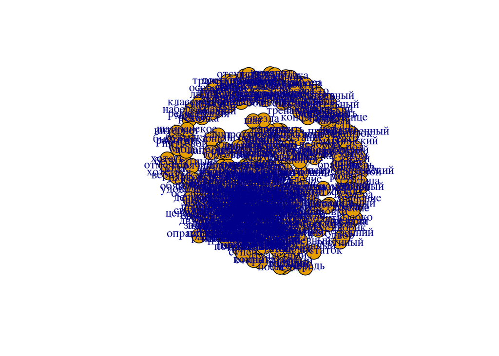

```r
plot(bigram_graph)
```

Ничего на графе не понятно. Попробуем перерисовать.

До этого мы использовали визуализацию в igraph, но есть альтернативный способ визуализации - ggraph.

Для более подробного знакомства посмотрите документацию пакета: https://cran.r-project.org/web/packages/ggraph/ggraph.pdf Также ответы на интересующие вас вопросы при построении сетей (и не только!) можно искать на stackoverflow.com

Пакет ggraph по своей сути похож на уже известный вам ggplot2 - в них обоих визуализация прописывается слоями. Но для того, чтобы его использовать, нужно создать графовый объект с помощью пакета igraph, что мы и сделали чуть выше

```r
library(ggraph)
set.seed(2019)
```

Рисуем сеть (попробуйте запускать частями, чтобы посмотреть разделение на слои)

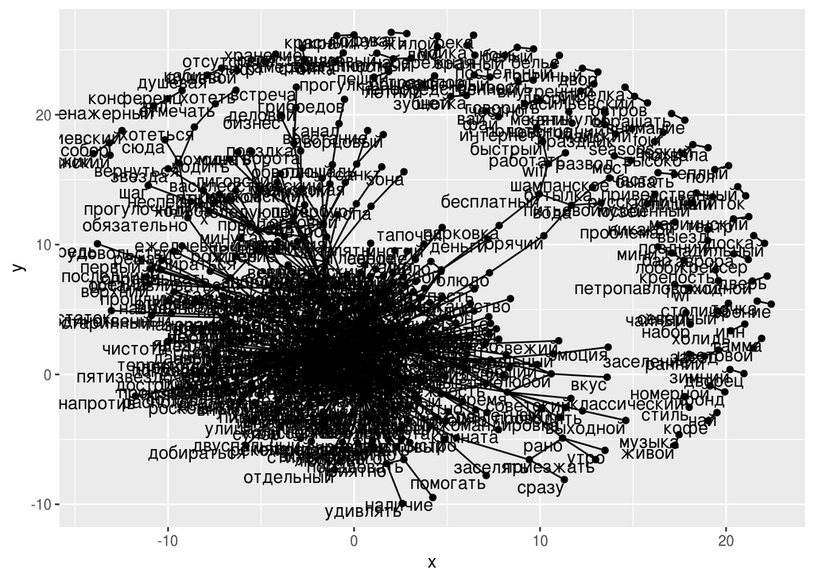

```r
ggraph(bigram_graph, layout = "fr") +
  geom_edge_link() +
  geom_node_point() +
  geom_node_text(aes(label = name), vjust = 1, hjust = 1)
```

Получилось не очень понятно. Мы можем работать с этими сетями как с привычными нам сетями и применять различные функции, например фильтрацию:

- посчитаем степень

```r
V(bigram_graph)$degree = degree(bigram_graph, mode = 'total')
```

- удалим вершины, у которых степень меньше 5

```r
bigram_graph=delete_vertices(bigram_graph,V(bigram_graph)$degree < 5)
```

В этом случае уже видно гораздо лучше

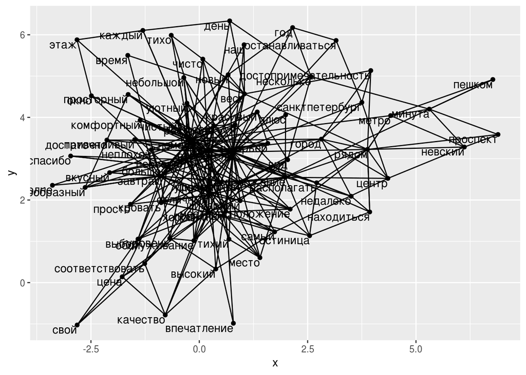

```r
ggraph(bigram_graph, layout = "fr") +
  geom_edge_link() +
  geom_node_point() +
  geom_node_text(aes(label = name), vjust = 1, hjust = 1)
```

Сделаем график еще понятнее: добавим стрелки, указывающие порядок слов и зададим интенсивность цвета ребра в зависимости от частоты встречаемости биграммы

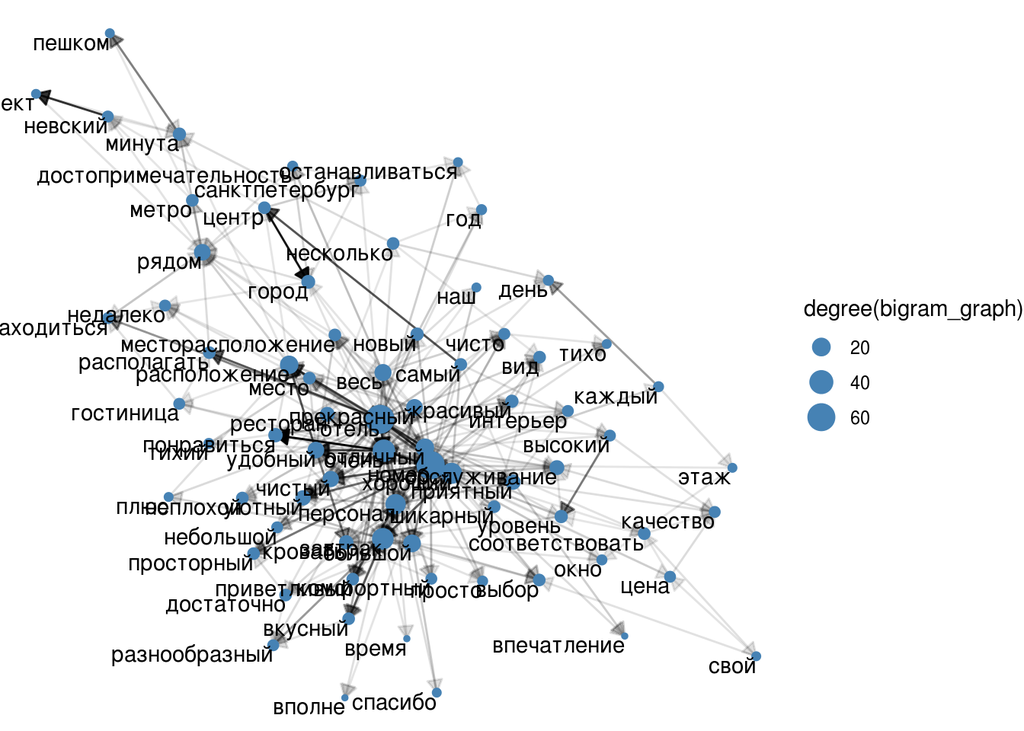

```r
# тип стрелок
a <- grid::arrow(type = "closed", length = unit(.1, "inches"))

ggraph(bigram_graph, layout = "fr") +
  geom_edge_link(aes(edge_alpha = n), show.legend = FALSE, arrow = a) +
  geom_node_point(aes(size = degree(bigram_graph)),
                  color = "steelblue") +
  geom_node_text(aes(label = name), color = 'black', vjust = 1, hjust = 1) +
  theme_void()
```

- Замените размер узла на betweenness

```r
ggraph(bigram_graph, layout = "fr") +
  geom_edge_link(...) +
  geom_node_point(...) +
  geom_node_text(...) +
  theme_void()
```

В сетях мы можем выделять сообщества. Посмотрим, что нам это даст в этом случае

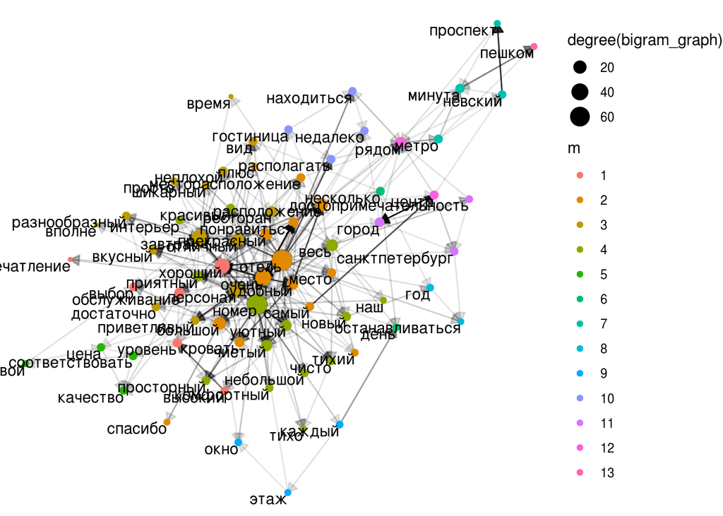

```r
bc <- walktrap.community(bigram_graph)
m = factor(membership(bc))

ggraph(bigram_graph, layout = "fr") +
  geom_edge_link(aes(edge_alpha = n), show.legend = FALSE, arrow = a) +
  geom_node_point(aes(size = degree(bigram_graph),
                      color = m)) +
  geom_node_text(aes(label = name), color = 'black', vjust = 1, hjust = 1) +
  theme_void()
```

- Что получилось в сообществах? Можно ли выделить интерпретируемые группы?

```r
sort(m)
```

```
##               хороший               высокий                 выбор
##                     1                     1                     1
##               уровень          обслуживание           впечатление
##                     1                     1                     1
##                 очень                 отель                 самый
##                     2                     2                     2
##               удобный          расположение            прекрасный
##                     2                     2                     2
##               большой                 тихий           понравиться
##                     2                     2                     2
##                 место               кровать                  плюс
##                     2                     2                     2
##     месторасположение               спасибо           приветливый
##                     2                     2                     3
##               вкусный              отличный              персонал
##                     3                     3                     3
##               завтрак         разнообразный              ресторан
##                     3                     3                     3
##              неплохой              шикарный                 время
##                     3                     3                     3
##            достаточно                просто                вполне
##                     3                     3                     3
##                   вид                 номер                уютный
##                     3                     4                     4
##                чистый                  весь            просторный
##                     4                     4                     4
##                 новый                 чисто                   наш
##                     4                     4                     4
##            комфортный              приятный              красивый
##                     4                     4                     4
##              интерьер             небольшой                  тихо
##                     4                     4                     4
##              качество                  цена                  свой
##                     5                     5                     5
##       соответствовать                  день             несколько
##                     5                     6                     6
##               невский                минута                 метро
##                     7                     7                     7
##              проспект                   год       останавливаться
##                     7                     8                     8
##                каждый                  окно                  этаж
##                     9                     9                     9
##           располагать            находиться             гостиница
##                    10                    10                    10
##              недалеко достопримечательность                 город
##                    10                    11                    11
##        санктпетербург                 центр                 рядом
##                    11                    12                    12
##                пешком
##                    13
## Levels: 1 2 3 4 5 6 7 8 9 10 11 12 13
```

```r
m[m==7]
```

```
##  невский   минута    метро проспект
##        7        7        7        7
## Levels: 1 2 3 4 5 6 7 8 9 10 11 12 13
```

```r
m[m==5]
```

```
##        качество            цена            свой соответствовать
##               5               5               5               5
## Levels: 1 2 3 4 5 6 7 8 9 10 11 12 13
```

**Задание**

1. Разделите отзывы на две части: 1) негативные – оценка < 3 и 2) позитивные – оценка == 5
2. Постройте для каждой из частей сеть (фильтрацию по степени можно сделать разную, т.к. негативных отзывов мало и степень там будет в целом меньше)
3. Выделите в сетях сообщества. Отличаются ли темы сообществ?